# Homework 7

Vedant Grover

## Problems

The *dugong.csv* data set contains data on 27 dugongs, which are marine mammals. Since we cannot ask a dugong how old it is (well, we can ask, but we wouldn’t likely get a clear answer!), its age needs to be estimated by other factors. The variables in *dugong.csv* are length (in meters) and age (in years).

Suppose we are interested in using the length of a dugong to predict its age. We can fit a regression model for this!

Credit: The *dugong.csv* file is from Data8 at UC-Berkeley.

### 1

- Read in the *dugong.csv* data set.
- Create a scatter plot with length on the x-axis and age on the y-axis; be sure to add descriptive axis labels and a title.
- Using `geom_smooth()` add the least-squares line to your plot and include the shaded band.

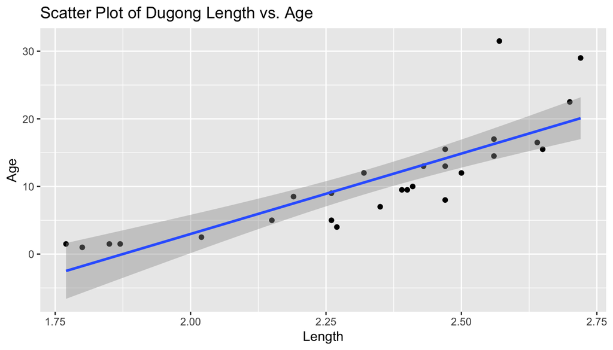

```r
# insert code here
dugongData = read.csv("../../data/dugong.csv")

scatter_plot <- ggplot(dugongData, aes(x = Length, y = Age)) +
  geom_point() +
  geom_smooth(method = "lm", se = TRUE) +  # Add the least-squares line with shaded band
  labs(x = "Length", y = "Age", title = "Scatter Plot of Dugong Length vs. Age")

print(scatter_plot)
```

### 2

- Using the dugong data, estimate the slope and intercept of a least squares linear model fit to age as the response variable and length as the explanatory variable.
- Compute the estimate slope and intercept using the regression formulas from lecture, and also using the `lm()` function.

How do the estimates using the two methods compare?

```r
# insert code here

mean_length <- mean(dugongData$Length)
mean_age <- mean(dugongData$Age)

numerator <- sum((dugongData$Length - mean_length) * (dugongData$Age - mean_age))
denominator <- sum((dugongData$Length - mean_length)^2)
slope_formula <- numerator / denominator

intercept_formula <- mean_age - slope_formula * mean_length

linear_model <- lm(Age ~ Length, data = dugongData)
slope_lm <- coef(linear_model)[2]  # Coefficient for Length
intercept_lm <- coef(linear_model)[1]  # Intercept

cat("Estimated slope using formula:", slope_formula, "\n")
```

```
## Estimated slope using formula: 23.77168
```

```r
cat("Estimated intercept using formula:", intercept_formula, "\n")
```

```
## Estimated intercept using formula: -44.56683
```

```r
cat("Estimated slope using lm():", slope_lm, "\n")
```

```
## Estimated slope using lm(): 23.77168
```

```r
cat("Estimated intercept using lm():", intercept_lm, "\n")
```

```
## Estimated intercept using lm(): -44.56683
```

The estimates obtained from the regression formulas and the lm() function are identical, given that both methods are calculating the least squares estimates, that is not surprising.

### 3

- Re-create the graphic from question 1.
- Add the regression model fit from the previous question (using the `lm()` method) to the plot in green. You may find `geom_abline()` useful for adding your fit model to the plot; run `?geom_abline` for more information on the input arguments. (This line should cover the line produced from `geom_smooth()`.)
- Using this estimated model, predict the age of a dugong that is 2.5 meters long.
- Plot this predicted value as a red point on your plot.

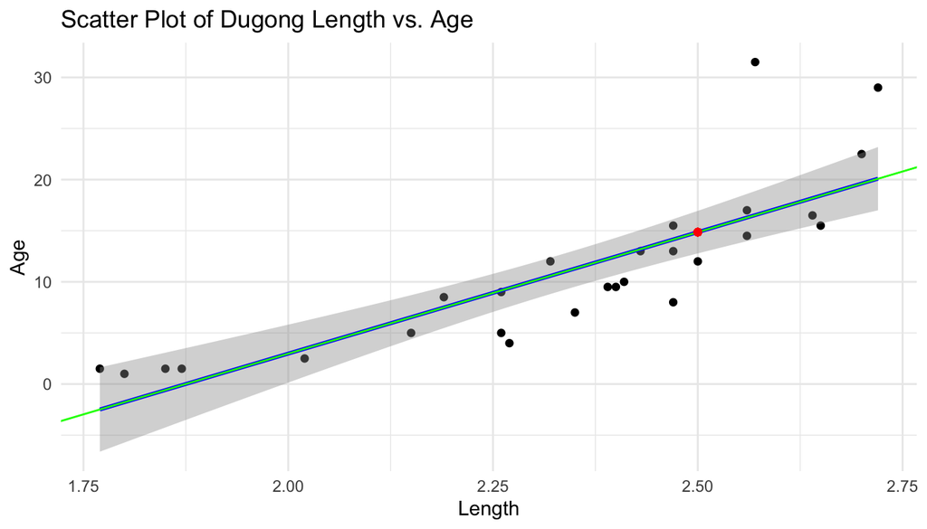

```r
# insert code here

scatter_plot <- ggplot(dugongData, aes(x = Length, y = Age)) +
  geom_point() +
  geom_smooth(method = "lm", se = TRUE, color = "blue") +  # Original smoothed line
  geom_abline(intercept = intercept_lm, slope = slope_lm, color = "green") +  # lm() regression line
  labs(x = "Length", y = "Age", title = "Scatter Plot of Dugong Length vs. Age") +
  geom_point(aes(x = 2.5, y = predict(linear_model, newdata = data.frame(Length = 2.5)), color = "Predicted Age"), color = "red") +
  scale_color_manual(values = c("Predicted Age" = "red")) +
  theme_minimal()

print(scatter_plot)
```

### 4

#### 4A

Display a plot of the residuals from your estimated model versus dugong length.

- Add to the plot a horizontal line at `y = 0`.
- In addition, use `geom_smooth()` to add a smooth curve to the residual plot to help identify any patterns.

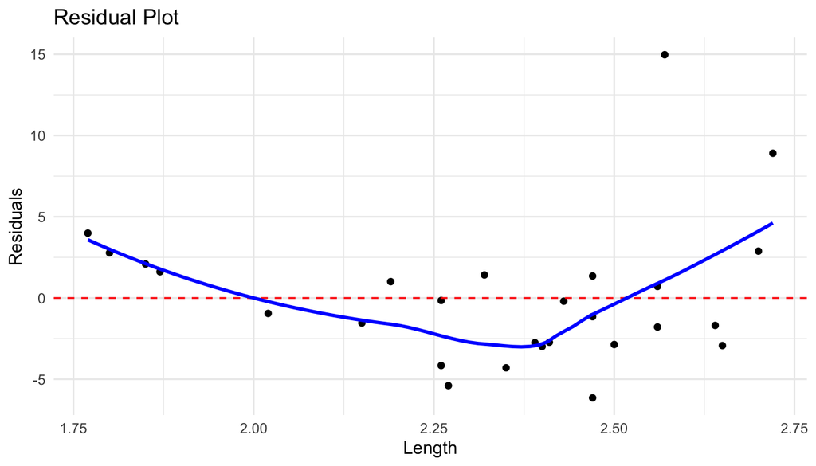

```r
# insert code here


linear_model <- lm(Age ~ Length, data = dugongData)

residuals <- resid(linear_model)

residual_plot <- ggplot(dugongData, aes(x = Length, y = residuals)) +
  geom_point() +
  geom_hline(yintercept = 0, color = "red", linetype = "dashed") +  # Horizontal line at y = 0
  geom_smooth(method = "loess", se = FALSE, color = "blue") +  # Smooth curve
  labs(x = "Length", y = "Residuals", title = "Residual Plot") +
  theme_minimal()

print(residual_plot)
```

#### 4B

Does the residual plot resemble random scatter around the horizontal line, or are there patterns in the residual plot which suggest the linear model may not be appropriate?

### 5 (OPTIONAL, i.e. will NOT be graded)

#### 5A

Compute a 95% confidence interval for the expected value of the age of dugongs that have a length of 2.5 meters, E(y|x=2.5). Re-create the graphic from question 3, and add a representation of this confidence interval as a vertical blue segment.

#### 5B

Compute a 95% *prediction* interval for the age of a future Dugong measured to have a length of 2.5 meters, Y|x=2.5. Re-create the graphic from question 4, and add a representation of this prediction interval as a vertical dotted black segment.